# Simulating Data Part 1

Leo Soccio

## Front Matter

```r
library(tidyverse)
library(mosaic)
```

## Task Set 1

### Part 1

1. Modify the code I sent you to generate data from a simple linear regression model but add 5 junk variables. (I think the code I sent has 2 junk variables.) Also modify the code so that you have 100 data points instead of 50.

```r
set.seed(12345)
x <- runif(n = 100, min = 5, max = 7)
epsilon <- rnorm(100, mean = 0, sd = sqrt(0.5))
y <- 3 - 5 * x + epsilon

junk1 <- runif(n = 100, min = 0, max = 1)
junk2 <- runif(n = 100, min = -5, max = 5)
junk3 <- runif(n=100, min=3, max = 5)
junk4 <- runif(n=100, min=10, max = 20)
junk5 <- runif(n=100, min=-2, max=0)
```

2. Create a data frame that has y, x, and the 5 junk variables.

```r
df <- data.frame(y,x,junk1,junk2,junk3,junk4,junk5)
```

3. Create a scatterplot showing the relationship between x and y and include a linear smoother to verify that the data generating process worked.

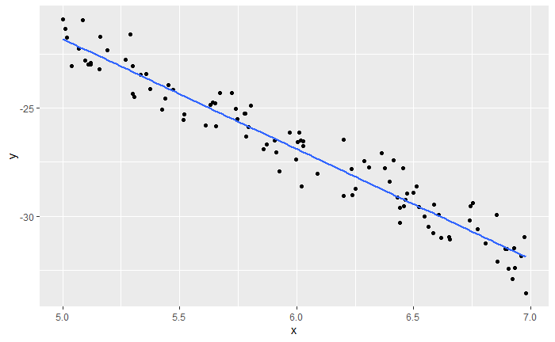

```r
ggplot(df, aes(x=x,y=y))+
  geom_point()+
  geom_smooth(method="lm", se=FALSE)
```

4. Perform a 80/20 training/testing split. Use a seed of 12345. I am not sure how/if you have covered this in 380. So, if you have no idea what that means, please ask instead of trying to figure out what I meant.

```r
set.seed(12345)
fold<-sample(1:nrow(df),nrow(df)/5)
train <- df%>%slice(-fold)
test <- df%>%slice(fold)
```

5. Using the train, implement backward elimination and note which variables were selected. Then build the model on the selected variables and write down the estimated regression equation. How close is the estimated equation to the true equation used when simulating the data?

```r
full_model <- lm(y~., data=train)
backward_model<-step(full_model,direction="backward",scope=formula(full_model))
```

```
Start:  AIC=-38.38
y ~ x + junk1 + junk2 + junk3 + junk4 + junk5

        Df Sum of Sq    RSS     AIC
- junk3  1      0.13  41.70 -40.125
- junk1  1      0.63  42.19 -39.179
- junk2  1      0.82  42.39 -38.813
<none>                41.57 -38.377
- junk5  1      2.51  44.07 -35.692
- junk4  1      2.64  44.20 -35.456
- x      1    638.48 680.05 183.211

Step:  AIC=-40.12
y ~ x + junk1 + junk2 + junk4 + junk5

        Df Sum of Sq    RSS     AIC
- junk1  1      0.58  42.28 -41.012
- junk2  1      0.85  42.55 -40.510
<none>                41.70 -40.125
- junk5  1      2.45  44.15 -37.552
- junk4  1      2.53  44.23 -37.415
- x      1    639.37 681.07 181.331

Step:  AIC=-41.01
y ~ x + junk2 + junk4 + junk5

        Df Sum of Sq    RSS     AIC
<none>                42.28 -41.012
- junk2  1      1.08  43.36 -40.993
- junk5  1      2.45  44.73 -38.503
- junk4  1      2.54  44.82 -38.345
- x      1    642.90 685.18 179.813
```

```r
summary(backward_model)
```

```
Call:
lm(formula = y ~ x + junk2 + junk4 + junk5, data = train)

Residuals:
     Min       1Q   Median       3Q      Max
-1.54425 -0.56504 -0.05194  0.54399  1.67154

Coefficients:
            Estimate Std. Error t value Pr(>|t|)
(Intercept)  3.09137    1.01373   3.049  0.00317 **
x           -5.10520    0.15118 -33.769  < 2e-16 ***
junk2       -0.04437    0.03205  -1.384  0.17034
junk4        0.06212    0.02927   2.123  0.03709 *
junk5        0.31252    0.14987   2.085  0.04045 *
---
Signif. codes:  0 ‘***’ 0.001 ‘**’ 0.01 ‘*’ 0.05 ‘.’ 0.1 ‘ ’ 1

Residual standard error: 0.7508 on 75 degrees of freedom
Multiple R-squared:  0.9392,    Adjusted R-squared:  0.936
F-statistic: 289.8 on 4 and 75 DF,  p-value: < 2.2e-16
```

6. Using the train, implement forward selection and note which variables were selected. Then build the model on the selected variables and write down the estimated regression equation. How close is the estimated equation to the true equation used when simulating the data?

```r
null_model <- lm(y~1,data=train)
forward_model<-step(null_model,direction="forward",scope=formula(full_model))
```

```
Start:  AIC=175.05
y ~ 1

        Df Sum of Sq    RSS     AIC
+ x      1    647.18  48.72 -35.672
<none>               695.90 175.054
+ junk5  1      7.20 688.70 176.222
+ junk1  1      4.63 691.27 176.520
+ junk3  1      1.29 694.61 176.906
+ junk2  1      0.78 695.12 176.965
+ junk4  1      0.71 695.19 176.973

Step:  AIC=-35.67
y ~ x

        Df Sum of Sq    RSS     AIC
+ junk4  1   2.37256 46.350 -37.665
+ junk5  1   2.21082 46.511 -37.387
+ junk2  1   2.14799 46.574 -37.279
<none>               48.722 -35.672
+ junk1  1   0.94460 47.777 -35.238
+ junk3  1   0.00269 48.719 -33.676

Step:  AIC=-37.67
y ~ x + junk4

        Df Sum of Sq    RSS     AIC
+ junk5  1   2.98641 43.363 -40.993
+ junk2  1   1.61541 44.734 -38.503
<none>               46.350 -37.665
+ junk1  1   0.87485 45.475 -37.190
+ junk3  1   0.05883 46.291 -35.767

Step:  AIC=-40.99
y ~ x + junk4 + junk5

        Df Sum of Sq    RSS     AIC
+ junk2  1   1.08048 42.283 -41.012
<none>               43.363 -40.993
+ junk1  1   0.81407 42.549 -40.510
+ junk3  1   0.10807 43.255 -39.193

Step:  AIC=-41.01
y ~ x + junk4 + junk5 + junk2

        Df Sum of Sq    RSS     AIC
<none>               42.283 -41.012
+ junk1  1   0.58412 41.698 -40.125
+ junk3  1   0.08801 42.195 -39.179
```

```r
summary(forward_model)
```

```
Call:
lm(formula = y ~ x + junk4 + junk5 + junk2, data = train)

Residuals:
     Min       1Q   Median       3Q      Max
-1.54425 -0.56504 -0.05194  0.54399  1.67154

Coefficients:
            Estimate Std. Error t value Pr(>|t|)
(Intercept)  3.09137    1.01373   3.049  0.00317 **
x           -5.10520    0.15118 -33.769  < 2e-16 ***
junk4        0.06212    0.02927   2.123  0.03709 *
junk5        0.31252    0.14987   2.085  0.04045 *
junk2       -0.04437    0.03205  -1.384  0.17034
---
Signif. codes:  0 ‘***’ 0.001 ‘**’ 0.01 ‘*’ 0.05 ‘.’ 0.1 ‘ ’ 1

Residual standard error: 0.7508 on 75 degrees of freedom
Multiple R-squared:  0.9392,    Adjusted R-squared:  0.936
F-statistic: 289.8 on 4 and 75 DF,  p-value: < 2.2e-16
```

### Part 2

1. Extract the estimated coefficients from the model you built using the selected variables in Step 5

```r
BWM_coefs<-coef(backward_model)
BWM_coefs
```

```
(Intercept)           x       junk2       junk4       junk5
 3.09137191 -5.10520285 -0.04436659  0.06212052  0.31252320
```

2. Extract the R^2, adjusted R^2, and the estimated value of sigma (standard deviation of the error terms) from the model you built using the selected variables in Step 5 (harder than 1)

```r
backward_summary<-summary(backward_model)
names(backward_summary)
```

```
 [1] "call"          "terms"         "residuals"     "coefficients"  "aliased"       "sigma"         "df"            "r.squared"
 [9] "adj.r.squared" "fstatistic"    "cov.unscaled"
```

```r
BWM_rsq <- backward_summary$r.squared
BWM_adjrsq <- backward_summary$adj.r.squared
BWM_sig <- backward_summary$sigma
BWM_stats <- c(BWM_rsq,BWM_adjrsq,BWM_sig)
BWM_stats
```

```
[1] 0.9392405 0.9360000 0.7508449
```

3. Extract the names of the variables selected from the backward elimination procedure (hardest task)

```r
BWM_vars<-variable.names(backward_model)[variable.names(backward_model)!="(Intercept)"]
BWM_vars
```

```
[1] "x"     "junk2" "junk4" "junk5"
```

```r
# If I did this wrong, please let me know. It feels like a pretty simple task, but you said it would be hard.
```

### Part 3

I want you to write a function for calculating a confidence interval for the population mean when the population standard deviation is known. R doesn’t actually have a function for this since it is so rare that the population standard deviation is known. (I think you took AP Stats. I am not sure if this was covered, but this is the z interval for the population mean.). The function should take 4 arguments: xbar, n, sigma, and cv which is the critical value (e.g., 1.96 for a 95% interval, 1.645 for a 90% interval, etc.). Set the default value of cv to 1.96. The interval should be calculated using:

$xbar +- cv * \frac{\sigma}{\sqrt(n)}$

The function should return 2 values: the lower bound for the interval and the upper bound for the interval. NOTE: Returning more than 1 value from an R function is a little tricky and requires a list. If you haven’t seen this before, it will take some googling.

```r
CIsd<-function(xbar,n,sigma,cv){
  upper <- xbar+cv*(sigma/(sqrt(n)))
  lower <- xbar-cv*(sigma/(sqrt(n)))
  ci <- c(upper,lower)
  return(ci)
}

CIsd(5,100,0.5,1.96) # testing
```

```
[1] 5.098 4.902
```

```r
5+1.96*0.5/sqrt(100)
```

```
[1] 5.098
```

start to think about how you could write a function to automatically generate the dataset. For instance, you might have arguments that specify the number of real variables, the number of junk variables, a vector of true coefficients, a value for sigma, etc. The function would then return a dataset.

## Task Set 2

### Part 1

Write a function to automatically generate the dataset. For instance, you might have arguments that specify the number of data points, number of real variables, number of junk variables, a vector of true coefficients, a value for sigma, etc. The function would then return a dataset.

```r
makedata <- function(n,coeffs,sd){
  x1 <- runif(n=n, min = 5, max = 7)
  x2 <- runif(n=n, min = -2, max = 4)
  epsilon <- rnorm(n, mean = 0, sd = sd)
  y <- coeffs[1]+coeffs[2]*x1+coeffs[3]*x2+epsilon
  j1 <- runif(n=n, min=-10, max=10)
  j2 <- runif(n=n, min=-1, max=1)
  jcategorical <- sample(c("a","b","c","d","e"),size=n,replace=TRUE)%>%
    as.factor()
  df <- data.frame(x1=x1,x2=x2,y=y, j1=j1, j2=j2, jcategorical=jcategorical)
}
testdata <- makedata(100,c(3,1.5,-2),sqrt(0.5))
testdata
```

| x1 | x2 | y | j1 | j2 | jcategorical |
| --- | --- | --- | --- | --- | --- |
| 6.414964 | 2.09950344 | 8.484799 | -4.97399685 | 0.190803710 | b |
| 6.289085 | 2.25983230 | 8.305319 | -2.21734185 | -0.113829109 | b |
| 5.779657 | 2.80138932 | 5.954015 | 6.87199211 | -0.402159410 | d |
| 6.397087 | 3.66447049 | 5.442394 | 9.61194863 | -0.393467187 | a |
| 6.088116 | -0.88012317 | 14.020739 | -3.87360611 | 0.147446414 | a |
| 5.452934 | -0.32814631 | 12.199639 | -4.59166444 | 0.861896672 | a |
| 5.969116 | 2.64557973 | 6.691881 | 2.45875194 | 0.619098873 | a |
| 6.586014 | -1.79931431 | 17.461665 | 2.47703603 | -0.129157882 | b |
| 5.011975 | 2.03150884 | 6.240101 | -8.88419562 | -0.287963450 | d |
| 5.375425 | 2.87660273 | 6.436713 | 4.90934420 | 0.033269465 | d |

[output cut: 90 more lines]

```r
makedata2 <- function(n, reals, junks, realbounds, junkbounds,coeffs,sd){
  df <- data.frame(matrix(nrow=n,ncol=0))

  for (i in 1:reals){
    dfx <- data.frame(x=runif(n=n,min=realbounds[2*i-1],max=realbounds[2*i]))
    colnames(dfx)[1] <- paste0("x",i)
    df <- cbind(df,dfx)
  }

  for(i in 1:junks){
    dfj <- data.frame(j=runif(n=n, min=junkbounds[2*i-1], max=junkbounds[2*i]))
    colnames(dfj)[1]<-paste0("j",i)
    df<-cbind(df,dfj)
  }

  y <- data.frame()
  epsilon <- rnorm(n, mean = 0, sd = sd)
  for(i in 1:n){
    ysingle <- data.frame(y=sum(unlist(df[i,1:reals])*coeffs)+epsilon[i])
    y <- rbind(y,ysingle)
  }
  df <- cbind(df,y)

  return(df)
}


testdata2 <- makedata2(100, 3, 2, c(-3,5,1,9,-6,3), c(-10,10,-1,1), c(1,2,3),sqrt(0.5))
```

### Part 2

Write a loop to cycle through the dataset and store all results. End result of loop should be a dataframe. Each row should summarize information about the dataset used in that iteration and the results of the variable selection. If you run the code again, do you get the same results? Try this for a small number of datasets (say 3) to see if you believe it is working or not at first. Then, you can expand.

```r
multidatasets <- function(n, count){
  overview<-data.frame()
  data <- list()
  for(i in 1:count){
    realcount <- sample(c(1:5),size=1)
    junkcount <- sample(c(1:5),size=1)
    realevenvec <- rep(c(0,11), length(realcount))
    junkevenvec <- rep(c(0,11), length(junkcount))
    coeffs <- runif(n=realcount, min=-10, max=10)
    sd <- runif(n=1, min=0.3, max=1.5)
    rbounds <- runif(n=2*realcount, min=-10,max=0)+realevenvec
    jbounds <- runif(n=2*junkcount,min=-10,max=0)+junkevenvec
    data[[i]] <- makedata2(n, realcount,junkcount, rbounds,jbounds,coeffs,sd)
    summary <- data.frame(Reals = realcount, Junks = junkcount,MeanY = mean(data[[i]]$y),
                          TrueEquation = paste("y=",paste0(c(round(coeffs[1:realcount],digits=2)), c(rep("x", realcount)),collapse=" + ")), sd=sd)
    overview<-rbind(overview,summary)
  }
  return(overview)
}

multidatasets(100,3)
```

| Reals | Junks | MeanY | TrueEquation | sd |
| --- | --- | --- | --- | --- |
| 2 | 4 | 1.9404695 | y= 6.25x + -9.64x | 0.9861929 |
| 2 | 1 | -0.5200031 | y= 0.41x + 0.37x | 0.4355855 |
| 5 | 3 | 18.7099248 | y= -5.82x + 7.41x + -9.25x + -5.13x + -9.37x | 0.9562160 |